# Project: Train a Quadcopter How to Fly

```
Episode = 1000, score = -278.837 (best = 339.456, best_episode= 330.000))best episode is: 330
```

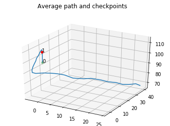

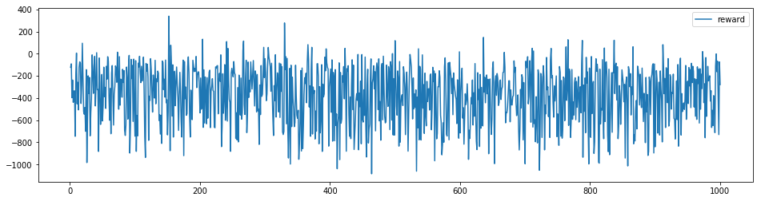

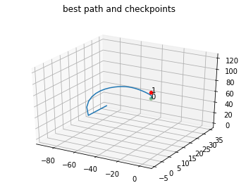

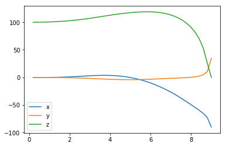

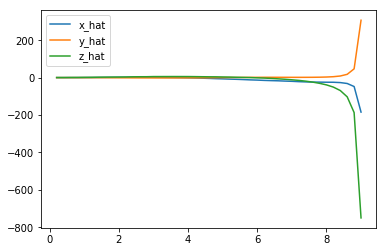

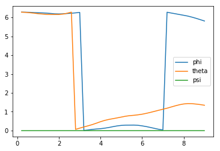

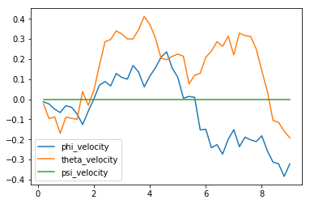

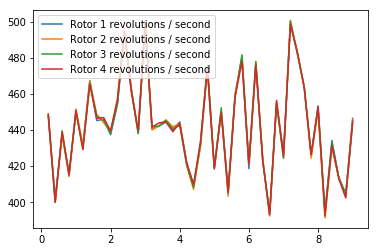

```python
from take_off_task import TakeOffTask
from agents.basic_agent import BasicAgent
task = TakeOffTask(target_pos=target_pos, runtime=runtime,init_pose=init_pose)
agent = BasicAgent(task)

ddpg_pipeline(task, agent, num_episodes=num_episodes)
```

```
Episode = 1000, score = 317.725 (best = 325.262, best_episode= 572.000)))0)best episode is: 572
```

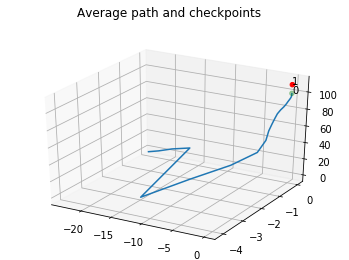

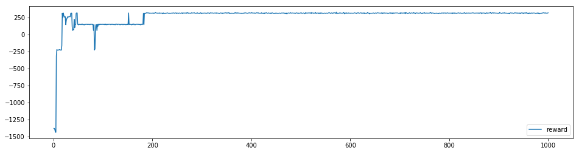

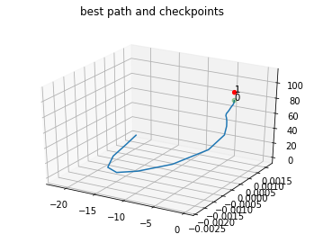

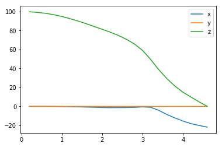

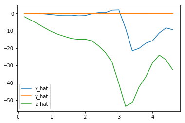

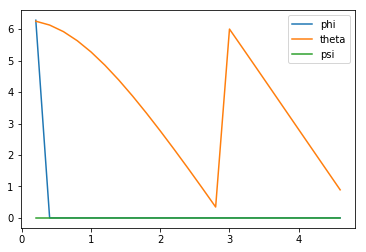

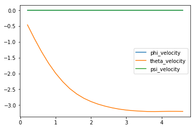

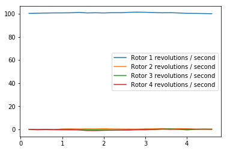

```python
from agents.udacity_agent import UdacityDDPG
from task import Task

task = TakeOffTask(target_pos=target_pos, runtime=runtime,init_pose=init_pose)

#create agent
agent = UdacityDDPG(task)

ddpg_pipeline(task, agent, 'takeoff', num_episodes=num_episodes)
```

## Plot the Rewards

Once you are satisfied with your performance, plot the episode rewards, either from a single run, or averaged over multiple runs.

```python
#I have plotted each of the rewards per episode over each agent above
```

## Reflections

**Question 1**: Describe the task that you specified in `task.py`. How did you design the reward function?

**Answer**:

I chose to design a take-off task, where I would pass in the initial (grounded) position and wanted the agent to reach a target waypoint, which I passed in as the exact co-ordinates of the grounded position but with a different z-value. I designed my reward function to:

- reward the agent if the initial distance (grounded position - target position) is greater than the current distance (current position - target position) and to punish the agent if it's initial distance is less than the current distance
- punish the agent fo it's angular velocities, therefore looking to maximise stabiliting by minimising the change in angles.

**Question 2**: Discuss your agent briefly, using the following questions as a guide:

- What learning algorithm(s) did you try? What worked best for you?
- What was your final choice of hyperparameters (such as $\alpha$, $\gamma$, $\epsilon$, etc.)?
- What neural network architecture did you use (if any)? Specify layers, sizes, activation functions, etc.

**Answer**: I chose to use a deeply deterministic policy gradient algorithm. I have submitted 2 versions of thiis model, the first is the stock-standard suggested actor-critic model with just a few dense layers in the actor. I then altered this model to create my own by modifying the neural network powering the Actor class.

In my modified network, I chose to model my data as if it is a time-series, therefore I reshaped the data points to a 2 dimensional input and modified my model to output 10 "frames" instead of the default 3 so that I could make more effective use of convolutional layers without sacrificing too many timesteps.

I then applied a series of 1D convolutional layers, and 2 pooling layers to help reduce over-fitting. For all of my layers, I applied batch normalisation to normalise the layer values and reduce the covariance shift as well as dropout layers to ensure a better rounded training experience for the entire network. I found the original Udacity model and my model performed fairly similarly with only slight tweaks to hyperParameters and the actor's network. I therefore believe that the main factor for bettering an RL solution is to focus on your definition of the reward function. I'd also like to spend more time exploring the effect of modifying the critic model / network.

My final choice of hyperparameters were for the default actor-critic model: gamma - 0.99,epsilon - 0.15, sigma - 0.25, tau - 0.05 My final choice of hyperparameters were for my altered actor-critic model: gamma - 0.9,epsilon - 0.05, sigma - 0.25, tau - 0.01

**Question 3**: Using the episode rewards plot, discuss how the agent learned over time.

- Was it an easy task to learn or hard?
- Was there a gradual learning curve, or an aha moment?
- How good was the final performance of the agent? (e.g. mean rewards over the last 10 episodes)

**Answer**:

By analysing the best agent (my actor-critic implementatioin) it's clear that the task itself was easy to learn as the agent seems to not need a large amount of learning and appears to have an initial "aha" moment followed by intermittent decreases presumably due to exploration coupled together with the way that the noise function generates outcomes. With that being said, the task itself was flawed / not-well defined by myself as the agent never learned to actually . "take off" but it did learn how to earn large rewards over time - key learning from this was the importance of the reward function.

Another learning was the importance of the environment itself. The physics sim module in this project doesn't have a "floor" and thus a take-off task does not really match the reality of an item "taking-off" as from the start of our sim, the agent will free-fall instead of be stationary which affects the agents learning decisions. I feel like this point makes it extremely difficult to train your agent as the external forces from the start acting against your agent will means you need to not only teach your agent to take off but to first hover and stabilise itself, then to move up to the final waypoint.

**Question 4**: Briefly summarize your experience working on this project. You can use the following prompts for ideas.

- What was the hardest part of the project? (e.g. getting started, plotting, specifying the task, etc.)
- Did you find anything interesting in how the quadcopter or your agent behaved?

**Answer**:

The hardest part of this project was the reward function and how to create a function that correctly penalises or rewards the agent across all combinations of actions and state-space. I tried many iterations of reward functions but struggled to find one that worked effectively for the take-off task without sacrificing the agent and environment's independence.

Yes, particularly by analysing the reward graph and realsing that agents go through good and bad patches based on the exploit-exploration dilemma and then comparing that to the performance of the random / basic agent's reward function. It's clear that we've developer a "smart" agent or an agent that can learn from previous experiences which is amazing.